# Prediction Assignment

Mark Wan

11/20/2020

# **Introduction**

The goal of this study is to apply machine learning techniques to predict exercise types based on activity data.

The data for this project come from this source: http://web.archive.org/web/20161224072740/http:/groupware.les.inf.puc-rio.br/har.

Reference for dataset and literature: Ugulino, W.; Cardador, D.; Vega, K.; Velloso, E.; Milidiu, R.; Fuks, H. Wearable Computing: Accelerometers’ Data Classification of Body Postures and Movements. Proceedings of 21st Brazilian Symposium on Artificial Intelligence. Advances in Artificial Intelligence - SBIA 2012. In: Lecture Notes in Computer Science. , pp. 52-61. Curitiba, PR: Springer Berlin / Heidelberg, 2012. ISBN 978-3-642-34458-9. DOI: 10.1007/978-3-642-34459-6_6.

# **Analysis**

## **Load Data**

```r
#download.file("https://d396qusza40orc.cloudfront.net/predmachlearn/pml-training.csv","training.csv")
#download.file("https://d396qusza40orc.cloudfront.net/predmachlearn/pml-testing.csv","testing.csv")
training_raw <- read.csv('training.csv')
testing_raw <- read.csv('testing.csv')
```

## **Clean Data**

The following code chunk coerces relevant variables to time and factor variables. Note some of these variables will not be used in final machine algorithm.

```r
training <- training_raw
cols <- c('user_name','new_window','num_window','classe')
training[cols] <- lapply(training[cols],as.factor)
training$cvtd_timestamp <- ts(training$cvtd_timestamp)
dim(training)
```

```
## [1] 19622   160
```

```r
testing <- testing_raw
cols <- c('user_name','new_window','num_window')
testing[cols] <- lapply(testing[cols],as.factor)
testing$cvtd_timestamp <- ts(testing$cvtd_timestamp)
```

## **Data Partitition**

```r
inTrain <- createDataPartition(training$classe,p=0.7,list=FALSE)
training_set <- training[inTrain,]
testing_set <- training[-inTrain,]
```

## **Pre-processing**

The following code removes columns with high proportion of NA values (threshold set at 90%). It then removes columns with near-zero variance as these variables do not provide a significant amount of information for classification.

```r
NA_cols <- sapply(training,function(x)mean(is.na(x)))>0.90
training_set <- training_set[,NA_cols==FALSE]
testing_set <- testing_set[,NA_cols==FALSE]
testing <- testing[,NA_cols==FALSE]
dim(training_set)
```

```
## [1] 13737    93
```

```r
NZ_cols <- nearZeroVar(training_set)
training_set <- training_set[,-NZ_cols]
testing_set <- testing_set[,-NZ_cols]
testing <- testing[,-NZ_cols]
dim(training_set)
```

```
## [1] 13737    59
```

Given that the objective is to classify exercise activities, most of the useful information would be contained in numeric variables. These variables will be the focus for the rest of the machine learning algorithm.

```r
num_col <- character()
for (name in names(training_set)){
  if ((class(training_set[,name])=='numeric')|(name=='classe')) {
    num_col <- append(num_col,name)
  }
}

training_set <- training_set[num_col]
testing_set <- testing_set[num_col]
testing <- testing[num_col[!num_col %in% "classe"]]
dim(training_set)
```

```
## [1] 13737    28
```

The correlation plot shows a small number of predictors are strongly correlated. These predictors will be separated into independent components using Principle Component Analysis.

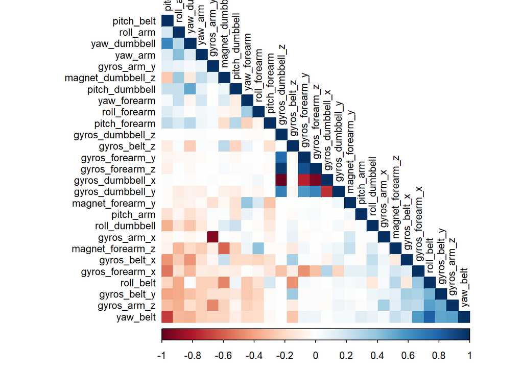

```r
corrs <- cor(subset(training_set,select=-c(classe)))
corrplot(corrs, order = "FPC", method = "color", type = "lower", tl.cex = 0.8, tl.col = rgb(0, 0, 0))
```

## **Principle Component Analysis**

```r
library(RANN)
preProc <- preProcess(subset(training_set,select=-c(classe)),method='pca',thresh=0.9)
training_set_PC <- predict(preProc,subset(training_set,select=-c(classe)))
training_set <- cbind(training_set_PC,training_set$classe)
names(training_set)[which(names(training_set)=='training_set$classe')] <- 'classe'
dim(training_set)
```

```
## [1] 13737    16
```

```r
testing_set_PC <- predict(preProc,subset(testing_set,select=-c(classe)))
testing_set <- cbind(testing_set_PC,testing_set$classe)
names(testing_set)[which(names(testing_set)=='testing_set$classe')] <- 'classe'

testing_PC <- predict(preProc,testing)
```

The SVD variance graph below shows that variance in predictors explained by PCs reduces exponentially with increased number of PCs. Hence, the PCs generated by PCA above should be a representative set of predictors for classification.

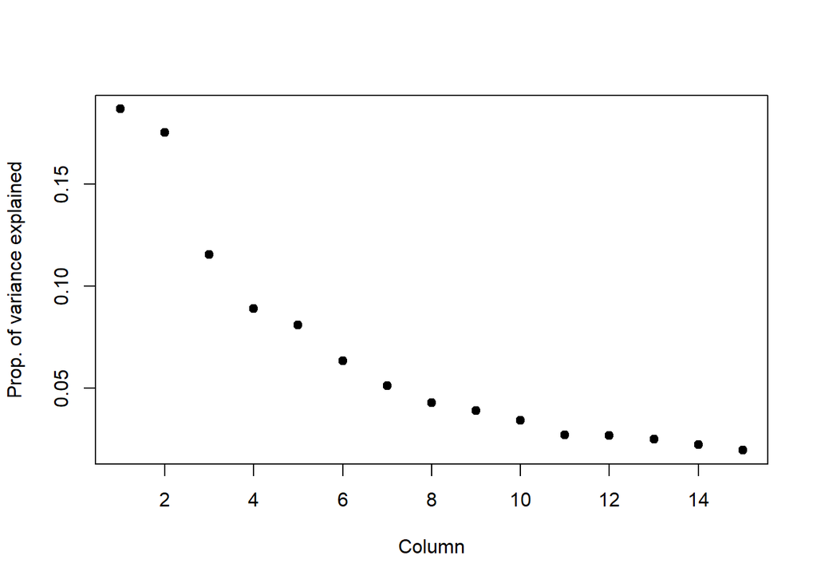

```r
svd1 <- svd(training_set_PC)
plot(svd1$d^2/sum(svd1$d^2), xlab = "Column", ylab = "Prop. of variance explained", pch = 19)
```

The following sections contain code chunks for different machine learning algorithms. The best model will be selected for the final test.

## **Model Selection A - Decision Tree**

```r
controlRF <- trainControl(method="cv", number=5, verboseIter=FALSE)
modelFit_dt <- train(classe~.,method='rpart',data=training_set,trControl=controlRF,preProcess=c('center','scale'))
modelFit_dt$finalModel
```

```
## n= 13737
##
## node), split, n, loss, yval, (yprob)
##       * denotes terminal node
##
## 1) root 13737 9831 A (0.28 0.19 0.17 0.16 0.18)
##   2) PC7>=-0.3422885 8521 5504 A (0.35 0.14 0.23 0.11 0.16)
##     4) PC12>=0.5630182 2695 1223 A (0.55 0.15 0.053 0.082 0.17) *
##     5) PC12< 0.5630182 5826 3988 C (0.27 0.14 0.32 0.13 0.15) *
##   3) PC7< -0.3422885 5216 3776 B (0.17 0.28 0.08 0.24 0.23) *
```

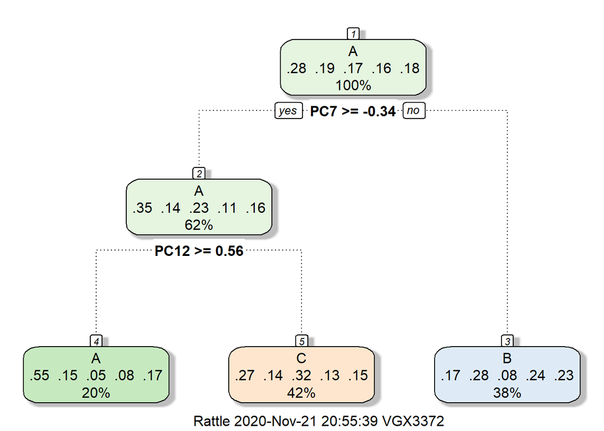

```r
fancyRpartPlot(modelFit_dt$finalModel)
```

```r
pred_dt <- predict(modelFit_dt,testing_set)
confMat_dt <- confusionMatrix(testing_set$classe,pred_dt)
accuracy_dt <- confMat_dt$overall[1]
print(paste("Decision Tree OOB accuracy = ",accuracy_dt))
```

```
## [1] "Decision Tree OOB accuracy =  0.343075615972812"
```

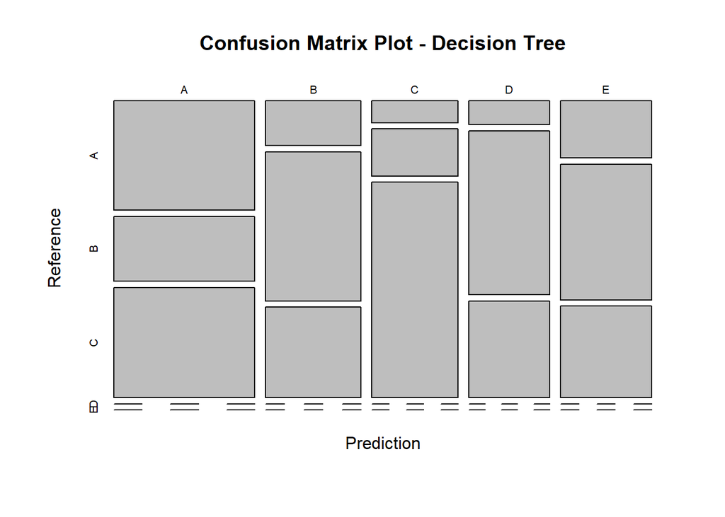

```r
plot(confMat_dt$table,main="Confusion Matrix Plot - Decision Tree")
```

## **Model Selection B - Random Forest**

```r
modelFit_rf <- train(classe~.,method='rf',data=training_set,trControl=controlRF,preProcess=c('center','scale'))
modelFit_rf$finalModel
```

```
##
## Call:
##  randomForest(x = x, y = y, mtry = param$mtry)
##                Type of random forest: classification
##                      Number of trees: 500
## No. of variables tried at each split: 2
##
##         OOB estimate of  error rate: 3.25%
## Confusion matrix:
##      A    B    C    D    E class.error
## A 3871   16   10    3    6 0.008960573
## B   60 2537   43   11    7 0.045522950
## C   10   43 2314   21    8 0.034223706
## D   16    8   93 2120   15 0.058614565
## E    6   21   31   18 2449 0.030099010
```

```r
pred_rf <- predict(modelFit_rf,testing_set)
confMat_rf <- confusionMatrix(testing_set$classe,pred_rf)
accuracy_rf <- confMat_rf$overall[1]
print(paste("Random Forest OOB accuracy = ",accuracy_rf))
```

```
## [1] "Random Forest OOB accuracy =  0.969073916737468"
```

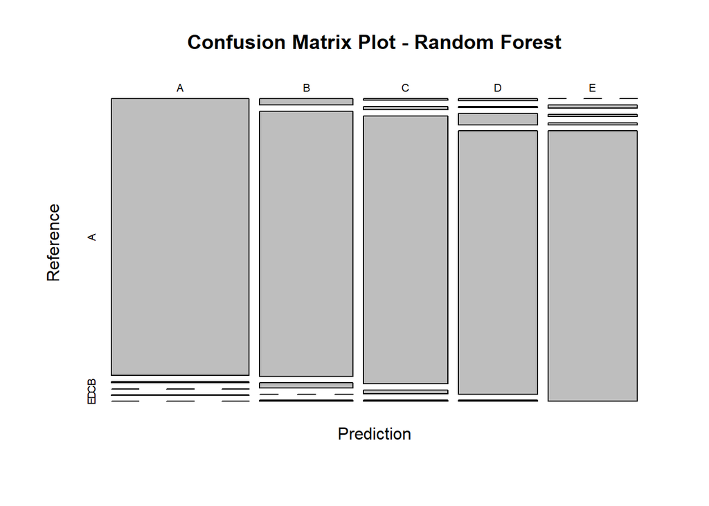

```r
plot(confMat_rf$table,main="Confusion Matrix Plot - Random Forest")
```

## **Model Selection C - Generalized Boosting Model**

```r
modelFit_gbm <- train(classe~.,method='gbm',data=training_set,trControl=controlRF,preProcess=c('center','scale'),verbose=FALSE)
modelFit_gbm$finalModel
```

```
## A gradient boosted model with multinomial loss function.
## 150 iterations were performed.
## There were 15 predictors of which 15 had non-zero influence.
```

```r
pred_gbm <- predict(modelFit_gbm,testing_set)
confMat_gbm <- confusionMatrix(testing_set$classe,pred_gbm)
accuracy_gbm <- confMat_gbm$overall[1]
print(paste("GBM OOB accuracy = ",accuracy_gbm))
```

```
## [1] "GBM OOB accuracy =  0.787255734919286"
```

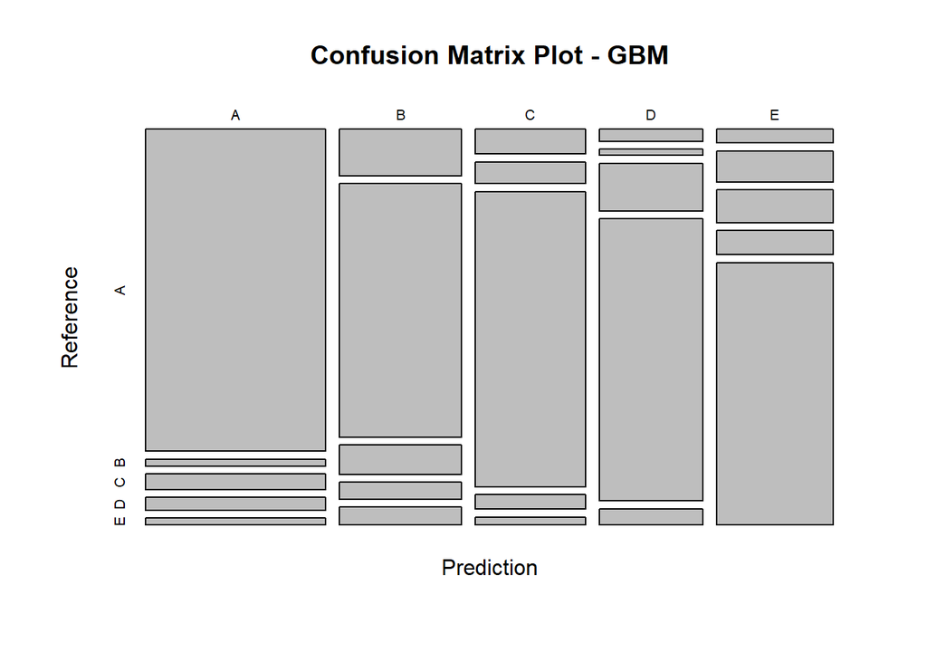

```r
plot(confMat_gbm$table,main="Confusion Matrix Plot - GBM")
```

## **Model Selection D - Support Vector Machine**

```r
training_set_prestd <- subset(training_set, select=-c(classe))
preObj <- preProcess(training_set_prestd,method=c("center","scale"))
training_set_std <- cbind(predict(preObj,training_set_prestd),training_set$classe)
names(training_set_std)[which(names(training_set_std)=='training_set$classe')] <- 'classe'

testing_set_prestd <- subset(testing_set, select=-c(classe))
preObj <- preProcess(testing_set_prestd,method=c("center","scale"))
testing_set_std <- cbind(predict(preObj,testing_set_prestd),testing_set$classe)
names(testing_set_std)[which(names(testing_set_std)=='testing_set$classe')] <- 'classe'

preObj <- preProcess(testing,method=c("center","scale"))
testing_std <- predict(preObj,testing)

modelFit_svm <- svm(classe~.,data=training_set_std,cross=5)
```

```r
pred_svm <- predict(modelFit_svm,testing_set_std)
confMat_svm <- confusionMatrix(testing_set_std$classe,pred_svm)
accuracy_svm <- confMat_svm$overall[1]
print(paste("svm accuracy = ",accuracy_svm))
```

```
## [1] "svm accuracy =  0.884791843670348"
```

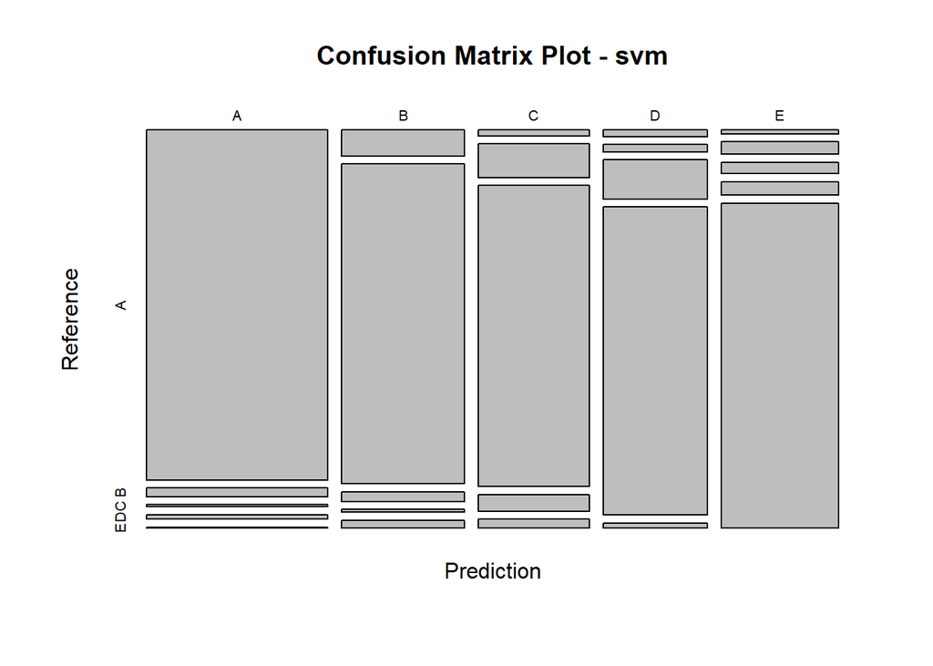

```r
plot(confMat_svm$table,main="Confusion Matrix Plot - svm")
```

## **Model Selection E - Combined**

```r
predDf <- data.frame(pred_dt,pred_rf,pred_gbm,pred_svm,classe=testing_set$classe)
modelFit_comb <- train(classe~.,data=predDf,method='gam')
pred_comb <- predict(modelFit_comb,predDf)
confMat_comb <- confusionMatrix(predDf$classe,pred_comb)
accuracy_comb <- confMat_comb$overall[1]
print(paste("Combined OOB accuracy = ",accuracy_comb))
```

```
## [1] "Combined OOB accuracy =  0.472047578589635"
```

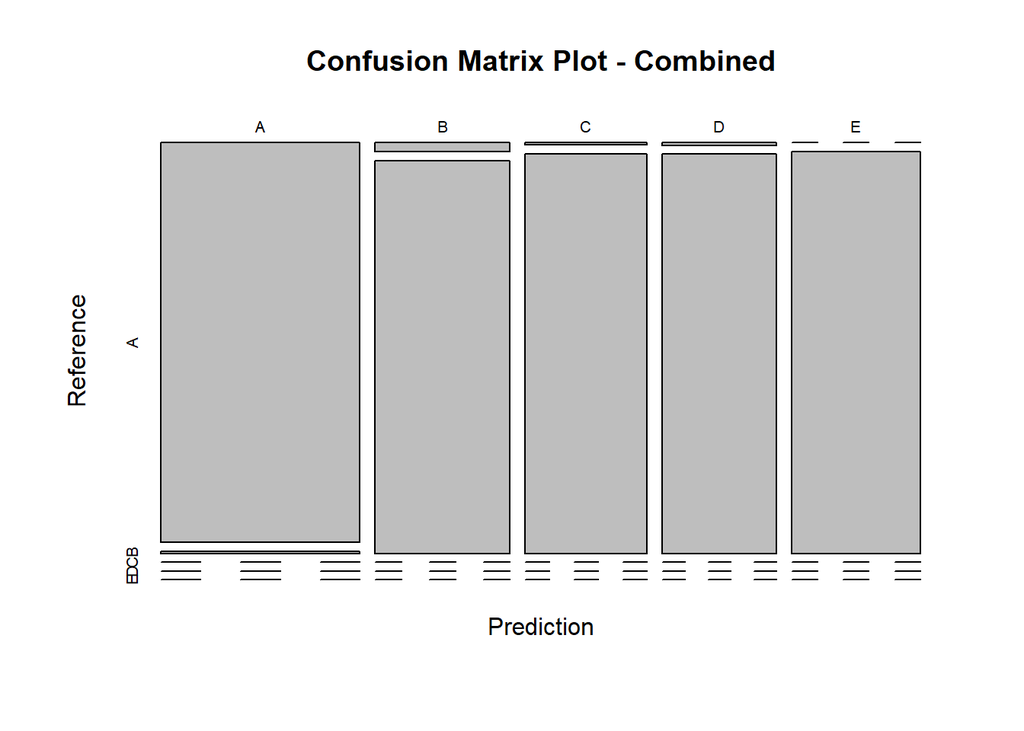

```r
plot(confMat_comb$table,main="Confusion Matrix Plot - Combined")
```

## **Summary**

The table below presents summary of accuracy values for all classfiers explored.

| Classifier | Accuracy (Out-of-Sample estimate) |
| --- | --- |
| Decision Tree | 0.3430756 |
| Random Forest | 0.9690739 |
| GBM | 0.7872557 |
| SVM | 0.8847918 |
| Combined | 0.4720476 |

## **Evaluation**

The most accurate in-sample model was used for testing. This approach is not ideal given that the most accurate in-sample model may also be overfitted to the training set.

```r
data.frame(case=c(1:dim(testing)[1]),Prediction=predict(modelFit_rf,testing_PC))
```

```
##    case Prediction
## 1     1          B
## 2     2          A
## 3     3          B
## 4     4          A
## 5     5          A
## 6     6          E
## 7     7          D
## 8     8          B
## 9     9          A
## 10   10          A
## 11   11          B
## 12   12          C
## 13   13          B
## 14   14          A
## 15   15          E
## 16   16          E
## 17   17          A
## 18   18          B
## 19   19          B
## 20   20          B
```